# Week 2-1 In-class Exercise

# 1. Getting Started with Python

Programs are made of instructions called *statements*. In this lecutre you'll learn your first Python statements and how to use the Jupyter Notebook to experiment with and run programs. Instructions perform an *action* on *inputs* and produce a *result*. In the example below `print` is the action and the words `Hello World` are the input to the function.

Copy this code into the cell below:

```
print("Hello World")
```

Execute the cell by pressing `Ctrl-Enter` or clicking the "Play" button above:

```python
print ("Hello World")
```

```
Hello World
```

Cells can be edited. Edit the cell above to change "Hello World" to your name and re-run the cell. If you're just learning to program it's important to see how the action and the input relate to one and other. The statement begins with the action and the input is in parentheses `(` and `)`. Statements are run one at a time, from top to bottom. The first statement of a program is always on the first line, just like the first word of a book. The program below performs the print action multiple times with different input.

```
print("Roses are red")
print("Violets are blue")
```

```python
print("Roses are red")
print("Violets are blue")
```

```
Roses are red
Violets are blue
```

```python
print ("I love python")
```

```
I love python
```

Add `print` instructions to the cell above to complete the poem. **Do you see how they are executed in order?**

## Comments

A *comment* is a part of a program that's ignored by Python. Comments are meant for the humans. Comments explain what code is doing to someone who is trying to read it. Comments make code more clear and easy to read. Comments begin with the hash `#` character. Here's an example:

```
# The next line prints "Hello World"
print("Hello World")
```

Copy the code into this cell:

```python
# The next line prints "Hello World"
print("Hello World")
```

```
Hello World
```

Notice that the comment is a different color! Try placing the `#` before the `print` function an re-running the cell. **What happens when you comment out the print statement?** If you're just getting started with programming put a comment before every line of code that explains what the next line does. The commens will help you remember instructions.

## Importing Packages

There is a core set of Python statements that are always available, including the `print` function. To use the full power of Python programs access add-on functions inside of `packages`. Anyone can create a Python package and make it available for other people to use. Jupyter, for example, is a Python package. The `import` statement makes a package available to a program. This statement imports the `math` package.

```
from math import *
```

Copy and run the instruction.

```python
from math import *
```

```python
math.sqrt(25)
```

```
---------------------------------------------------------------------------
NameError                                 Traceback (most recent call last)
<ipython-input-11-8584a6df8e30> in <module>
----> 1 math.sqrt(25)

NameError: name 'math' is not defined
```

# 2. Variables, Expressions, and Statements

## 2.1 Variables

A variable is a named place in the memory where a programmer can store data and later retrieve the data using the variable “name” and programmers get to choose the names of the variables

A variable is like a box. The box contains the value of a literal that is placed in it using the assignment operator (`=`). Variables are essential for every realistic Python program and take some time to understand if this is the first time you have used them.

Variables are created when they are first assigned. This statement:

```
x = 42
```

Is just like doing this:

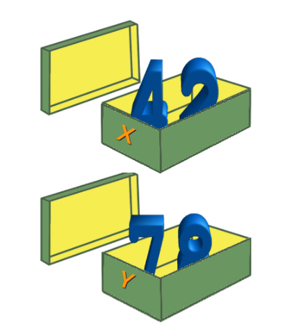

The literal value `42` is placed in a box called `x`. Variables can be used anywhere in a program where you would use a literal (including some surprising places, but we'll talk about that later). Copy this python code into the next cell and run it:

```
x = 42
print(x)
```

**Notice how `x` is now a stand-in for the number `42`?**

## Variable Assignment and Usage

When you assign a variable for the first time the variable name is *created*. In Python there's no need to declare a variable in advance. Running the code in the cell below creates a variable named `ironman`.

```
ironman = 'The contents of ironman'
```

The assignment operator (`=`) places a new value into a variable. Unlike mathematical expressions, which state something that's true for all time, variable assignment changes the contents of the variable. Variables often will have a succession of different values inside of them during the execution of a program. Copy the code example into the next cell:

Executing the statement produces no output, but it creates the variable `ironman`. Once created the variable can be *used* in any place that expects a value. For example:

```
print("ironman is:", ironman)
```

Copy the print statement into the next cell.

```python
ironman="Tony Stark"
print ("iron man is:", ironman)
```

```
iron man is: Tony Stark
```

Try changing the literal on the right side of the equal sign and rerunning the cells in this section.

**Watch out!** Variables have to be assigned before they can be used.

Try this:

```
print(some_variable_not_here)
```

## Variable Names

Variables can only have certain characters in their name to avoid confusion with Python syntax such as operators. There are a few rules to remember when you name your variables:

1. A variable name must start with a letter or the underscore (`_`) character (no numbers).
2. A variable name can only contain alpha-numeric characters and underscores (A-Z, a-z, 0-9, and _ )
3. Variable names are case-sensitive (age, Age and AGE are three different variables)

The best thing to do is to name your variables descriptively, so that you know what they're used for.

What style you choose is up to you. Just remember, you are the programmer who is most likely to be confused by your code.

## Variables to Hold Constants

A good use of variables is to avoid repitition of constants in your program.

## Updating and Changing Variables

A variable is just a way to get Python to *remember* a value for you. You can use or change the remembered value at any time. That means that when you read code you should watch for assignments and remember the new value of a variable in your program. With some practice you can do it with ease. However, right now it's probably pretty confusing. Here's an example program where the value of `a` changes a few times:

```
a = 10
a = a + 100
a = a * 2
a = a - 50
print(a)
```

Can you see how `a` changes from line to line? Enter the program into the next cell and execute it. *Did you guess right?*

```python
a = 10
a = a + 100
a = a * 2
a = a - 50
print(a)
```

```
170
```

Now let's do something really cool. The previous example is pretty simple, so you might be easily able to track the changing value of `a`. Don't worry if you are having trouble because the *debugger* can do it for you! Enable debugging using the switch next to the bug in the upper right of this tab. Set a breakpoint on line 1 and step through the program.

## Data Types

Variables are how programs use the computer's RAM memory. Each variable is held in a location in memory and the location is associated with the *type* of data that's there. In many programming languages variables must only contain one type of value. For example, an integer or a string. In Python variables take any type of value depending on what they're assigned. Python is *dynamically typed*, meaning that variables can have any type and that type can change. That means a programmer has to be careful. Mixing variable types when performing operations is usually not allowed. The `type()` function shows you the type of a variable or literal. Enter this program into the next cell and run it:

```
print("The type of 10 is", type(10))
print("The type of 10.5 is", type(10.5))
print("The type of 'Python' is:", type('Python'))
```

```python
print("The type of 10 is", type(10))
print("The type of 10.5 is", type(10.5))
print("The type of 'Python' is:", type('Python'))
```

```
The type of 10 is <class 'int'>
The type of 10.5 is <class 'float'>
The type of 'Python' is: <class 'str'>
```

Now let's update the program to use a variable instead of literals:

```
a = 10
print("The type of a is", type(a))
a = 10.5
print("The type of a is", type(a))
a = 'Python'
print("The type of a is", type(a))
```

**Does the cell print what you expect?**

Try executing the cell in the debugger. In the `VARIABLES` pane notice that the type of the variable is visible to you if you flip the switch to the table view.

```python
a = 10
print("The type of a is", type(a))
a = 10.5
print("The type of a is", type(a))
a = 'Python'
print("The type of a is", type(a))
```

```
The type of a is <class 'int'>
The type of a is <class 'float'>
The type of a is <class 'str'>
```